# Lab_6: Text Mining

Sarah Van Norden

9/23/2020

You should load in `dplyr`, (or `data.table` if you want to work that way), `ggplot2` and `tidytext`. If you don’t already have `tidytext` then you can install with

```r
library(tidytext)
library(dplyr)
library(data.table)
```

```r
library(ggplot2)
library(readr)
```

### read in Medical Transcriptions

Loading in reference transcription samples from https://www.mtsamples.com/

```r
mt_samples <- read_csv("https://raw.githubusercontent.com/USCbiostats/data-science-data/master/00_mtsamples/mtsamples.csv")
mt_samples <- mt_samples %>%
  select(description, medical_specialty, transcription)#to select only the fields you will use

head(mt_samples)
```

```
## # A tibble: 6 x 3
##   description                  medical_specialty   transcription
##   <chr>                        <chr>               <chr>
## 1 A 23-year-old white female ~ Allergy / Immunolo~ "SUBJECTIVE:,  This 23-year-~
## 2 Consult for laparoscopic ga~ Bariatrics          "PAST MEDICAL HISTORY:, He h~
## 3 Consult for laparoscopic ga~ Bariatrics          "HISTORY OF PRESENT ILLNESS:~
## 4 2-D M-Mode. Doppler.         Cardiovascular / P~ "2-D M-MODE: , ,1.  Left atr~
## 5 2-D Echocardiogram           Cardiovascular / P~ "1.  The left ventricular ca~
## 6 Morbid obesity.  Laparoscop~ Bariatrics          "PREOPERATIVE DIAGNOSIS: , M~
```

```r
mt_samples$transcription[1]#Shows you the first transcription record
```

```
## [1] "SUBJECTIVE:,  This 23-year-old white female presents with complaint of allergies.  She used to have allergies when she lived in Seattle but she thinks they are worse here.  In the past, she has tried Claritin, and Zyrtec.  Both worked for short time but then seemed to lose effectiveness.  Sh…
```

## Question 1: What specialties do we have?

We can use `count()` from `dplyr` to figure out how many different catagories do we have? Are these catagories related? overlapping? evenly distributed?

```r
table(mt_samples$medical_specialty)
```

```
##
##          Allergy / Immunology                       Autopsy
##                             7                             8
##                    Bariatrics    Cardiovascular / Pulmonary
##                            18                           372
##                  Chiropractic    Consult - History and Phy.
##                            14                           516
##    Cosmetic / Plastic Surgery                     Dentistry
##                            27                            27
##                   Dermatology          Diets and Nutritions
##                            29                            10
##             Discharge Summary        Emergency Room Reports
##                           108                            75
##                 Endocrinology          ENT - Otolaryngology
##                            19                            98
##              Gastroenterology              General Medicine
##                           230                           259
##         Hematology - Oncology     Hospice - Palliative Care
##                            90                             6
##        IME-QME-Work Comp etc.      Lab Medicine - Pathology
##                            16                             8
##                       Letters                    Nephrology
##                            23                            81
##                     Neurology                  Neurosurgery
##                           223                            94
##       Obstetrics / Gynecology                  Office Notes
##                           160                            51
##                 Ophthalmology                    Orthopedic
##                            83                           355
##               Pain Management         Pediatrics - Neonatal
##                            62                            70
##     Physical Medicine - Rehab                      Podiatry
##                            21                            47
##       Psychiatry / Psychology                     Radiology
##                            53                           273
##                  Rheumatology                Sleep Medicine
##                            10                            20
## SOAP / Chart / Progress Notes             Speech - Language
##                           166                             9
##                       Surgery                       Urology
##                          1103                           158
```

```r
mt_samples %>%
  count(mt_samples$medical_specialty, sort = TRUE)
```

```
## # A tibble: 40 x 2
##    `mt_samples$medical_specialty`     n
##    <chr>                          <int>
##  1 Surgery                         1103
##  2 Consult - History and Phy.       516
##  3 Cardiovascular / Pulmonary       372
##  4 Orthopedic                       355
##  5 Radiology                        273
##  6 General Medicine                 259
##  7 Gastroenterology                 230
##  8 Neurology                        223
##  9 SOAP / Chart / Progress Notes    166
## 10 Obstetrics / Gynecology          160
## # ... with 30 more rows
```

## There are 40 different medical specialties in the dataset. While most of them represent distinct specialties, there are some that do not represent specialties per se, but rather functions, such as “Consult - History & Phy”, “Progress Notes”, “Discharge Summary”, “Emergency Room Reports” potentially overlap with the specialties to which they refer. Re: the distribution, if we are talking about the n of records, Surgery has many more records (more than double) than any other specialty, and some specialties toward the lower end of the distribution (e.g. Allergy, Hospice) have fewer than 10 records.

## Question 2

- Tokenize the the words in the `transcription` column
- Count the number of times each token appears
- Visualize the top 20 most frequent words

Explain what we see from this result. Does it makes sense? What insights (if any) do we get?

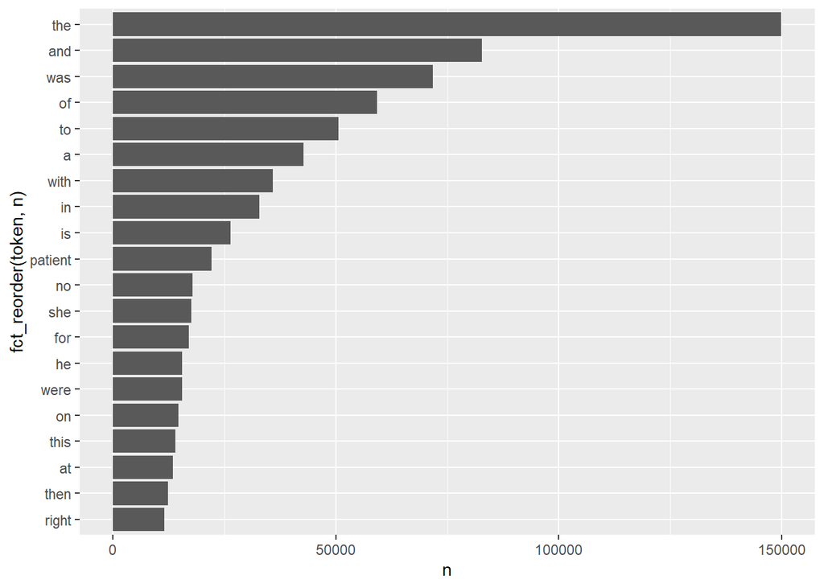

```r
library(dplyr)
library(forcats)#FYI forcats is included in tidyverse)
mt_samples %>%
  unnest_tokens(output = token, input = transcription)%>%
  count(token, sort = TRUE) %>%
  top_n(n = 20, wt = n) %>%
  ggplot(aes(x = n, y = fct_reorder(token, n)))+
  geom_col()
```

## What we see here is that the 20 most frequent words mostly include articles (the, a), prepositions (of, to, with, in, on) and conjunctions (and, with), i.e. words that do not relay a great deal of meaning. This makes sense, as we would expect that these commonly used connector or adverbial parts of speech would dwarf other more substantive tokens in their frequency within written or spoken narratives. The insight may be that our most meaningful/substantive words will appear with less frequency, i.e. lower down in the distribution of tokens.

## Question 3

- Redo visualization but remove stopwords before
- Bonus points if you remove numbers as well

```r
library(dplyr)
library(forcats)#FYI forcats is included in tidyverse)
as.character(seq(0, 100))
```

```
##   [1] "0"   "1"   "2"   "3"   "4"   "5"   "6"   "7"   "8"   "9"   "10"  "11"
##  [13] "12"  "13"  "14"  "15"  "16"  "17"  "18"  "19"  "20"  "21"  "22"  "23"
##  [25] "24"  "25"  "26"  "27"  "28"  "29"  "30"  "31"  "32"  "33"  "34"  "35"
##  [37] "36"  "37"  "38"  "39"  "40"  "41"  "42"  "43"  "44"  "45"  "46"  "47"
##  [49] "48"  "49"  "50"  "51"  "52"  "53"  "54"  "55"  "56"  "57"  "58"  "59"
##  [61] "60"  "61"  "62"  "63"  "64"  "65"  "66"  "67"  "68"  "69"  "70"  "71"
##  [73] "72"  "73"  "74"  "75"  "76"  "77"  "78"  "79"  "80"  "81"  "82"  "83"
##  [85] "84"  "85"  "86"  "87"  "88"  "89"  "90"  "91"  "92"  "93"  "94"  "95"
##  [97] "96"  "97"  "98"  "99"  "100"
```

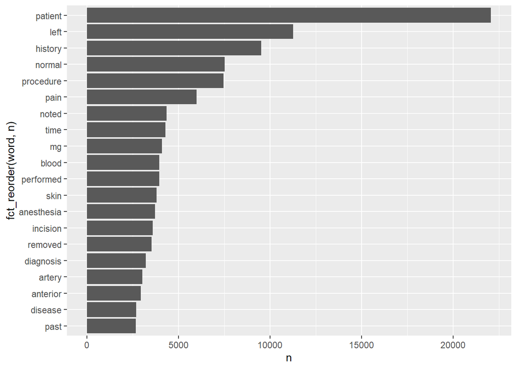

```r
mt_samples %>%
  unnest_tokens(word, transcription)%>%
  anti_join(tidytext::stop_words)%>%
  filter(!(word %in% as.character(seq(0, 100))))%>%
  count(word, sort = TRUE)%>%
  top_n(20, n)%>%
  ggplot(aes(x = n, y = fct_reorder(word, n)))+
  geom_col()
```

What do we see know that we have removed stop words? Does it give us a better idea of what the text is about?

## We now see much more meaningful and substantive medical terminology in the sorted list of tokens after eliminating the stopwords. It still gives us some fairly general medical terminology, but is much more focused on substance rather than connector and general parts of speech not specific to medicine.

# Question 4

repeat question 2, but this time tokenize into bi-grams.

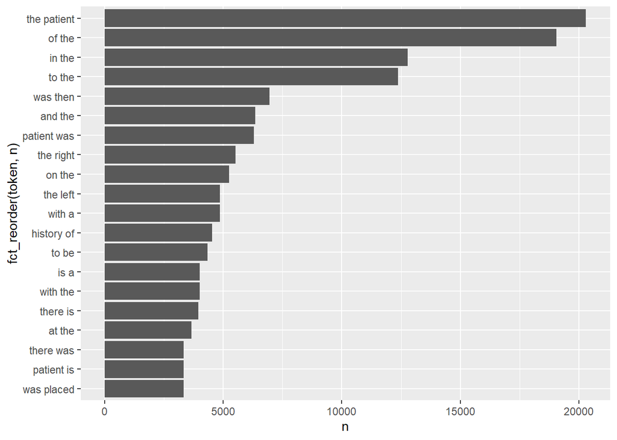

```r
mt_samples %>%
  unnest_ngrams(output = token, input = transcription, n = 2)%>%
  count(token, sort = TRUE) %>%
  top_n(n = 20, wt = n) %>%
  ggplot(aes(x = n, y = fct_reorder(token, n))) +
  geom_col()
```

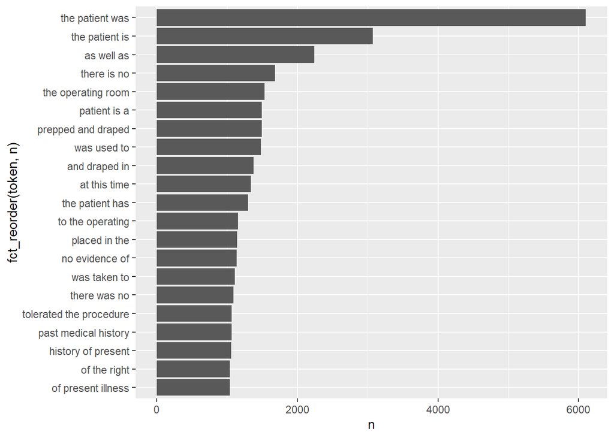

```r
mt_samples %>%
  unnest_ngrams(output = token, input = transcription, n = 3)%>%
  count(token, sort = TRUE) %>%
  top_n(n = 20, wt = n) %>%
  ggplot(aes(x = n, y = fct_reorder(token, n))) +
  geom_col()
```

How does the result change if you look at tri-grams?

## With bi-grams, we get a lot of results containing stop words. With tri-grams, we have fewer phrases containing stop words, and more phrases containing substantive medical terminology. However, we still have a lot of 3-word phrases that are not particularly revealing in terms of medical content (e.g. “as well as”, “there is no”, etc.). But nevertheless, filtering by 3-word phrases reveals more meaningful content.

# Question 5

Using the results you got from questions 4, pick a word and count the words that appears after and before it.

```r
library(tidyr)
mt_bigrams <- mt_samples %>%
  unnest_ngrams(output = token, input = transcription, n = 2,
                collapse = FALSE)%>%
  separate(col = token, into = c("word1", "word2"), sep = " ")%>%
  select(word1, word2)
mt_bigrams %>%
  filter(word1 == "anesthesia") %>%
  count(word2, sort = TRUE)
```

```
## # A tibble: 213 x 2
##    word2          n
##    <chr>      <int>
##  1 general      781
##  2 was          555
##  3 the          324
##  4 and          217
##  5 local        133
##  6 a             91
##  7 with          86
##  8 care          72
##  9 spinal        65
## 10 department    55
## # ... with 203 more rows
```

```r
library(tidyr)
mt_trigrams <- mt_samples %>%
  unnest_ngrams(output = token, input = transcription, n = 3)%>%
  separate(col = token, into = c("word1", "word2", "word3"), sep = " ")%>%
  select(word1, word2 ,word3)
mt_trigrams %>%
  filter(word2 == "anesthesia") %>%
  count(word1, word3, sort = TRUE)
```

```
## # A tibble: 861 x 3
##    word1        word3        n
##    <chr>        <chr>    <int>
##  1 general      was        155
##  2 endotracheal was        139
##  3 endotracheal the         79
##  4 general      the         64
##  5 of           the         64
##  6 monitored    care        48
##  7 of           a           47
##  8 from         and         41
##  9 of           bleeding    41
## 10 and          well        39
## # ... with 851 more rows
```

## From these results, we see that there are 213 different words (indicated by # of rows) that appear after the word “anesthesia” and 861 different word combinations that appear before or after “anesthesia” in this data file.

# Question 6

Which words are most used in each of the specialties. you can use `group_by()` and `top_n()` from `dplyr` to have the calculations be done within each specialty. Remember to remove stopwords. How about the most 5 used words?

```r
mt_samples %>%
  unnest_tokens(token, transcription)%>%
  anti_join(tidytext::stop_words, by = c("token" = "word")) %>%
  group_by(medical_specialty) %>%
  count(token) %>%
  top_n(5, n)
```

```
## # A tibble: 209 x 3
## # Groups:   medical_specialty [40]
##    medical_specialty    token         n
##    <chr>                <chr>     <int>
##  1 Allergy / Immunology allergies    21
##  2 Allergy / Immunology history      38
##  3 Allergy / Immunology nasal        13
##  4 Allergy / Immunology noted        23
##  5 Allergy / Immunology past         13
##  6 Allergy / Immunology patient      22
##  7 Autopsy              1            66
##  8 Autopsy              anterior     47
##  9 Autopsy              inch         59
## 10 Autopsy              left         83
## # ... with 199 more rows
```

## We see from this that, although there are some interesting results, even with the removal of the stop words we are not getting a lot of substance from this search. We see that a few particular words appear in the top 5 for each specialty, including “patient” and “history,” but otherwise there is a diverse range of words that appear. I think a better analysis potentially results from looking at ngrams of increasing size, to examine the clusters of words that appear together, which reveals more meaning.

# Question 7 - extra

Find your own insight in the data:

Ideas:

- Interesting ngrams
- See if certain words are used more in some specialties then others